# Mon rapport dynamique

Ceci est un rapport visant à illustrer ce que l’on peut faire avec R et Quarto. Il s’appuie sur une base **complètement fictive**.

# Description des variables de ma base

Voyons d’abord de quoi se compose notre base :

```
'data.frame':   451 obs. of  7 variables:
 $ Sexe             : chr  "Homme" "Femme" "Homme" "Homme" ...
 $ Fumeur           : chr  "Occasionnel" "Occasionnel" "Occasionnel" "Non" ...
 $ Poids            : chr  "Sous-poids" "Surpoids" "Moyen" "Sous-poids" ...
 $ Taux_de_glucose  : num  53.1 85.3 68.4 65.7 59.9 ...
 $ Pression_sanguine: num  51.3 83.7 78.8 67.6 62 ...
 $ Cholesterol_HDL  : num  53.2 48.5 45.3 34.1 55.1 ...
 $ Maladie          : int  0 1 0 1 0 0 1 1 0 0 ...
```

On sort des statistiques sur les différentes variables :

## Variables caractères

**Sexe**

| Sexe | n | Proportion |
| --- | --- | --- |
| Femme | 232 | 51 % |
| Homme | 219 | 49 % |

**Tabagisme**

| Fumeur | n | Proportion |
| --- | --- | --- |
| Non | 174 | 39 % |
| Occasionnel | 145 | 32 % |
| Souvent | 132 | 29 % |

**Poids**

| Poids | n | Proportion |
| --- | --- | --- |
| Moyen | 156 | 35 % |
| Sous-poids | 145 | 32 % |
| Surpoids | 150 | 33 % |

## Variables numériques

**Taux_de_glucose**

| Min | Moyenne | Mediane | Max |
| --- | --- | --- | --- |
| 41.51 | 70.66 | 70.46 | 96.32 |

**Pression_sanguine**

| Min | Moyenne | Mediane | Max |
| --- | --- | --- | --- |
| 33.04 | 71.15 | 71.08 | 101.36 |

**Cholesterol_HDL**

| Min | Moyenne | Mediane | Max |
| --- | --- | --- | --- |
| 20.60 | 50.17 | 49.81 | 81.93 |

**Maladie**

| Min | Moyenne | Mediane | Max |
| --- | --- | --- | --- |
| 0.00 | 0.47 | 0.00 | 1.00 |

# Graphiques d’analyse

Pour illustrer cela, on peut utiliser une boxplot avec un nuage de points pour se donner une idée de la distribution de la variable au sein des patients sains et malades :

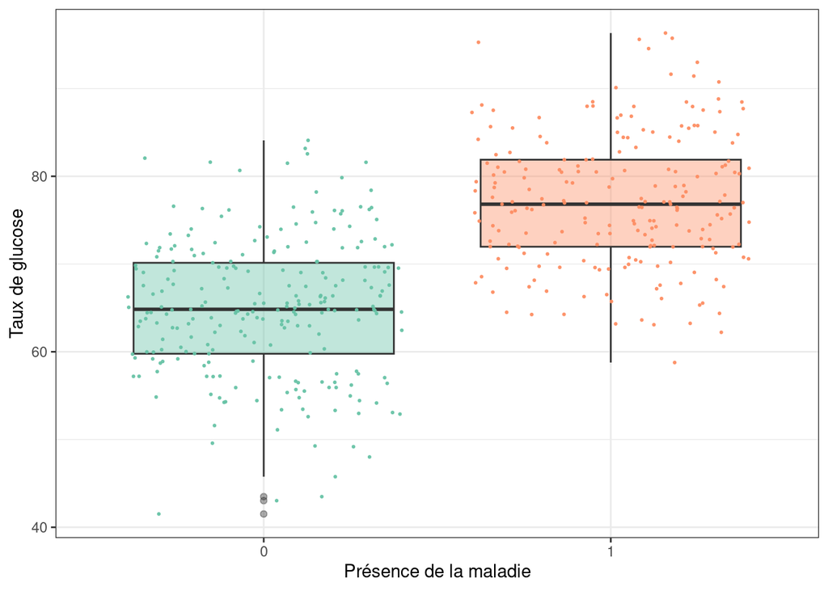

Figure 1: Taux de glucose et présence de la maladie

## Prévalence de la maladie, poids et sexe

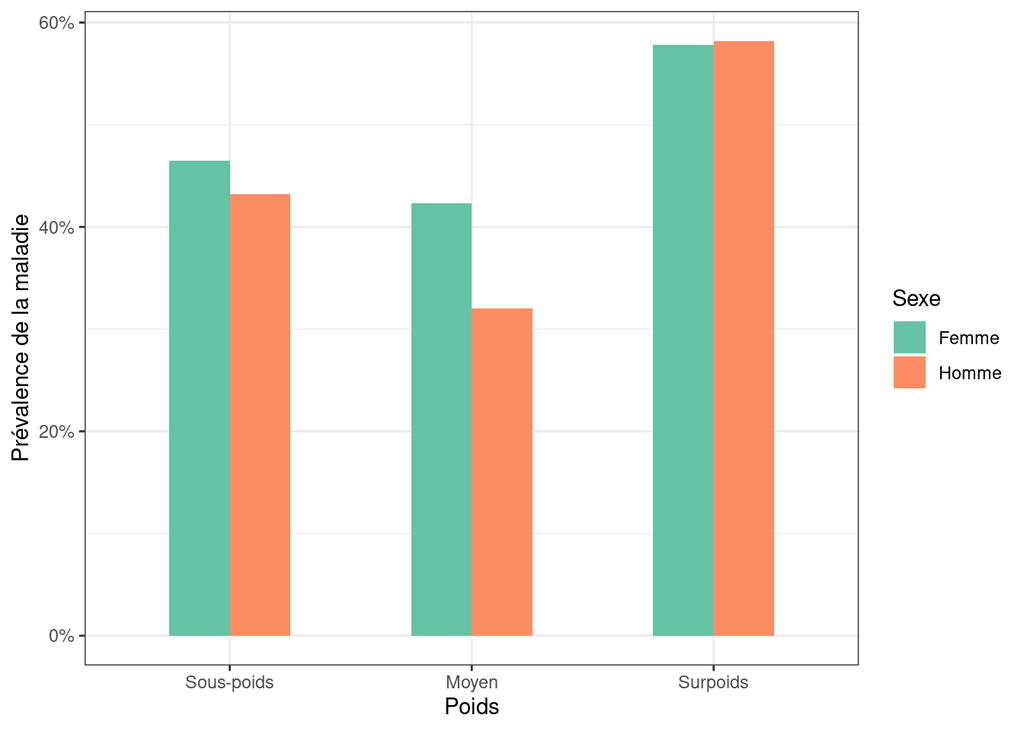

Figure 2: Sexe, poids et prévalence de la maladie

Y’a-t-il un lien entre la prévalence de la maladie et les autres variables? La Figure 1 semble montrer que les personnes malades ont des taux de glucose plus élevés que les non-malades. La Figure 2 semble montrer que les personnes en sous-poids et en surpoids sont plus touchées par la maladie, et que les femmes le sont plus que les hommes.

**Note**

Pour rappel, cette note s’appuie sur des données complètement fictives et ne devrait pas révolutionner la recherche scientifique.

**Caution**

L’utilisation des blocs d’annotation de Quarto peut être addictive, merci de ne pas en abuser.